# Methods 4 – Portfolio Assignment 3

## 2. Choose an estimand / outcome

We recommend that you choose whether the person survived as the outcome - it's (a bit) interesting, and it forces you to do regression with a binary outcome :)

However, it's okay to do something else if you really want to :)

- **I will do as recommended :)**

## 3. Make a scientific model (i.e., a DAG)

Make a DAG that seems theoretically reasonable, and that includes some of the variables in the dataset. It can include unobserved variables too, if you want, but then you have to come up with them.

You might have to return to this point later on ;)

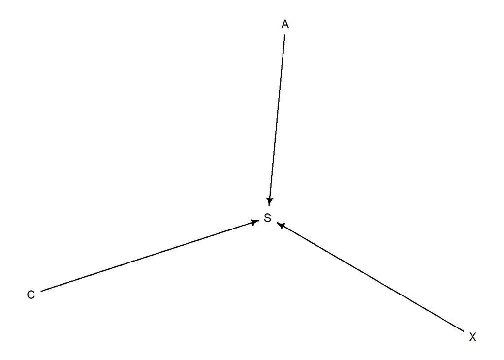

```r
dag <- dagitty( "dag {
    A -> S
    C -> S
    X -> S
}")

drawdag(dag)
```

Considering the variables available, i would expect survival to be predicted by sex, age and class. This is a very simple DAG, but it is based on my ignorance of the famous ship

## 4. Simulate data from the DAG

Use some reasonable or expected parameter values.

Use this to see if the DAG can give data that looks similar to what you have.

Maybe plot the simulated data to see if it looks right.

Also, this is one of those things which is nice to get comfy with :)

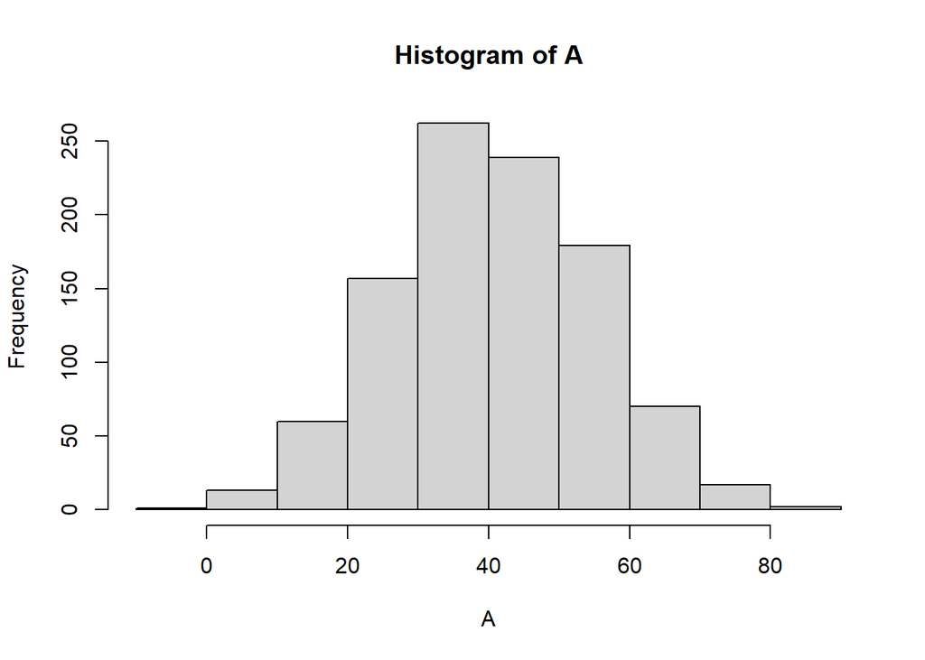

```r
# Age: I would expect a mean age of 40 and a std of 15. When sampling, some values might dip below 0, which of course isn't interpretable when dealing with age, but when simulating it should be okay. There were roughly 2200 people aboard the Titanic, but for simplicity I will sample 1000.
A = rnorm(1000, 40, 15)
hist(A)
```

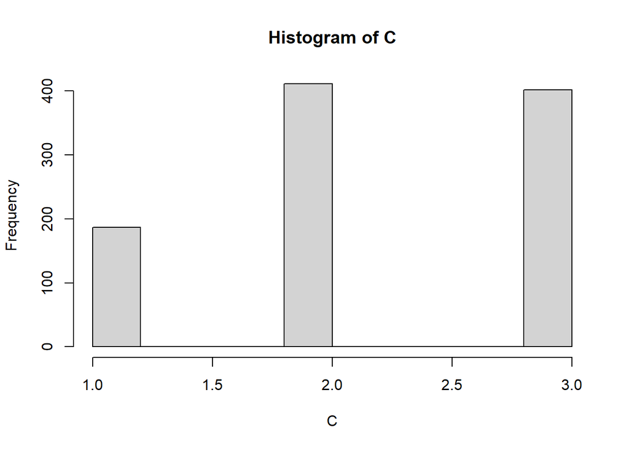

```r
# Class: I would expect less 1st class than 2nd and 3rd, as 1st class probably requires more space and requires more service.
C = sample(1:3, 1000, prob = c(0.2, 0.4, 0.4), replace=TRUE)
hist(C)
```

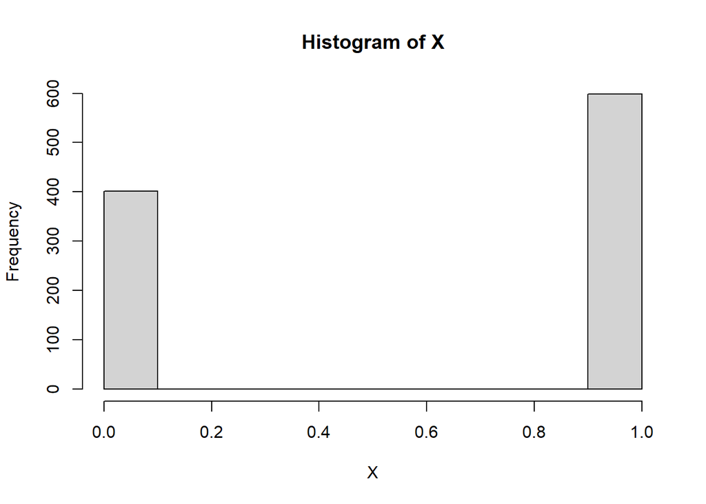

```r
# Sex: Based on the movie and stereotypes, I'd expect more men aboard than women due to the expensive tickets, and assuming that crew members are largely men. 1 = mean, 0 = women
X = rbinom(1000, 1, 0.6)
hist(X)
```

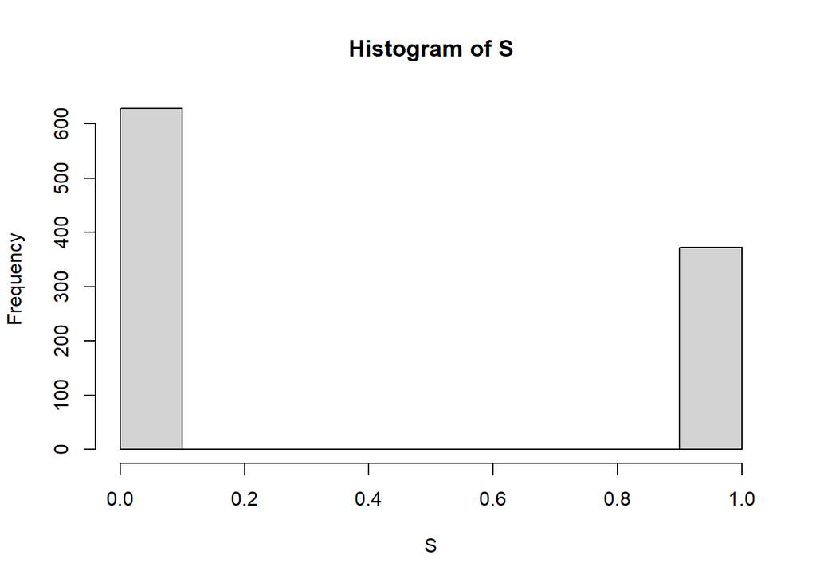

```r
# Survived: The "base" survival rate is sort of arbitrary, but i'd imagine less people to survive than not. Then again, i don't know how likely people are to survive a sinking ship. The weightings are based on the following: Age is scaled and weighted so that younger people are more likely to survive, higher class are more likely to survive and women are more likely to survive.
S = rbinom(1000, 1, prob = 0.4 + (-0.05)*scale(A) + (-0.05)*scale(C) + (-0.1)*scale(X))
hist(S)
```

```r
table(is.na(S)) # Checking to see if any of the values exceed 1 (or drop below 0) and become NA.
```

```
##
## FALSE
##  1000
```

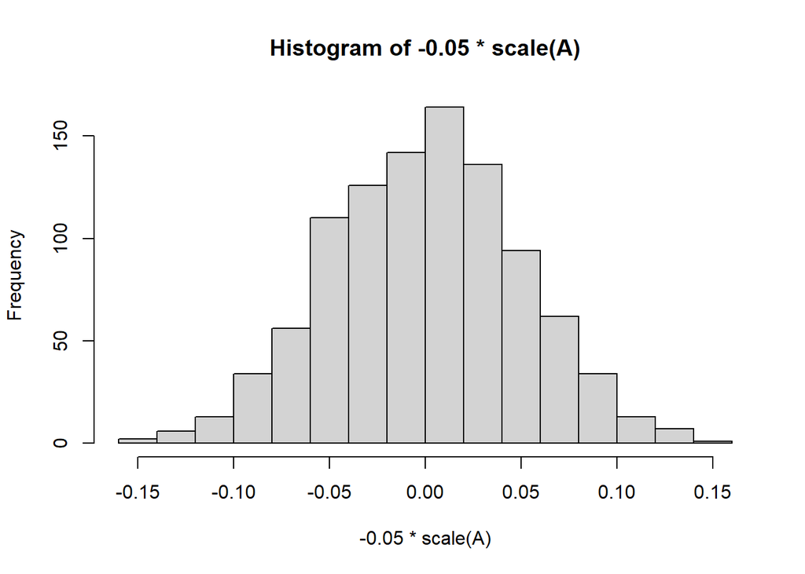

```r
# Checking weightings
hist(-0.05*scale(A))
```

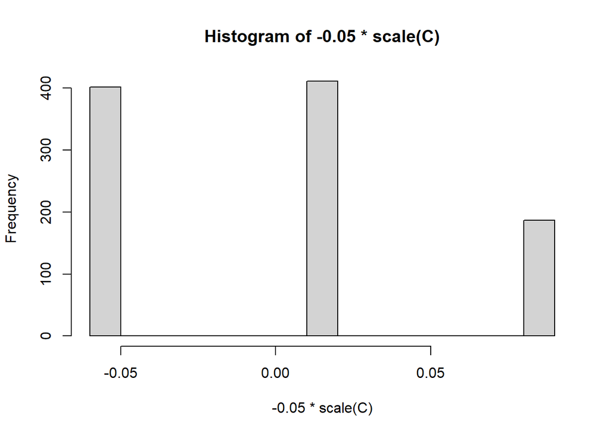

```r
hist(-0.05*scale(C))
```

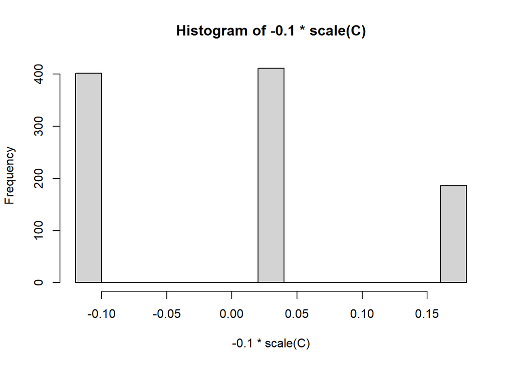

```r
hist(-0.1*scale(C))
```

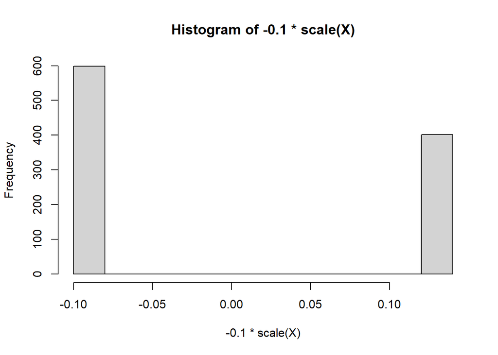

```r
hist(-0.1*scale(X))
```

```r
df_sim <- data.frame(A, C, X, S)
```

**Based on the plots above, i’d say my simulated data isn’t that far off from the real data.**

## 5. Make a statistical model

The whole thing :)

Include relevant predictors.

Remember to check for adjustment sets.

Figure out how to deal with binary and categorical variables.

Include interactions maybe.

Set priors. Use prior predictive checks for that.

Use MCMC to fit it. You can also try with quap and see if there's a difference.

**The statistical model is in the next segment. The relevant predictors, as implied by the DAG, are age, sex and class, therefore S ~ A + X + C. In the model, survived is a binary variable (although treated as an integer), so the posterior is a binomial distribution. There are random slopes for sex and for class, and age is a fixed effect. Priors are chosen based on prior predictive checks. Interactions will be explored when modelling the real data.**

## 6. Test the statistical model on the simulated data

Test that the conditional independencies implied by the DAG are also in the simulated data. If they aren't, something's probably wrong.

```r
# Standardizing
dat_sim = list(

  A = scale(df_sim$A),
  C = as.factor(df_sim$C),
  X = as.factor(df_sim$X),
  S = as.integer(df_sim$S)
)

# Using a modest prior
m1_1 <- ulam(
  alist(

    ## S ~ A + X + C

    S ~ dbinom(1, p),
    logit(p) <- aX[X] + aC[C] + bA*A,
    aX[X] ~ dnorm(0, 0.5),
    aC[C] ~ dnorm(0, 0.5),
    bA ~ dnorm(0, 0.5)

  ), data = dat_sim, log_lik = TRUE, refresh = 0
)
```

```
## Running MCMC with 1 chain, with 1 thread(s) per chain...
##
## Chain 1 finished in 4.7 seconds.
```

```r
# Very narrow priors
m1_2 <- ulam(
  alist(

    ## S ~ A + X + C

    S ~ dbinom(1, p),
    logit(p) <- aX[X] + aC[C] + bA*A,
    aX[X] ~ dnorm(0, 0.0001),
    aC[C] ~ dnorm(0, 0.0001),
    bA ~ dnorm(0, 0.0001)

  ), data = dat_sim, log_lik = TRUE, refresh = 0
)
```

```
## Running MCMC with 1 chain, with 1 thread(s) per chain...
##
## Chain 1 finished in 6.3 seconds.
```

```r
# Very large priors
m1_3 <- ulam(
  alist(

    ## S ~ A + X + C

    S ~ dbinom(1, p),
    logit(p) <- aX[X] + aC[C] + bA*A,
    aX[X] ~ dnorm(0, 10),
    aC[C] ~ dnorm(0, 10),
    bA ~ dnorm(0, 10)

  ), data = dat_sim, log_lik = TRUE, refresh = 0
)
```

```
## Running MCMC with 1 chain, with 1 thread(s) per chain...
##
## Chain 1 finished in 43.7 seconds.
```

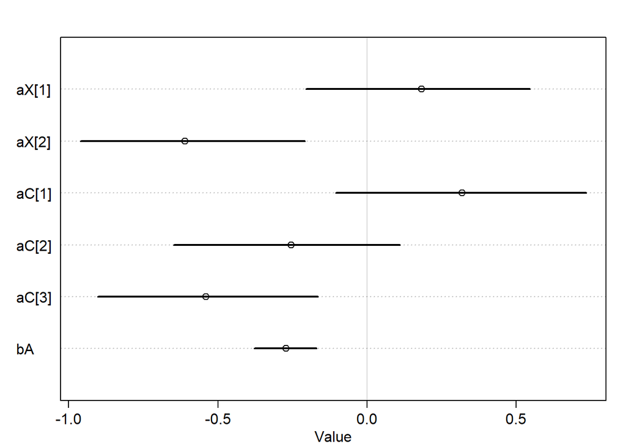

```r
precis_plot(precis(m1_1, depth = 2))
```

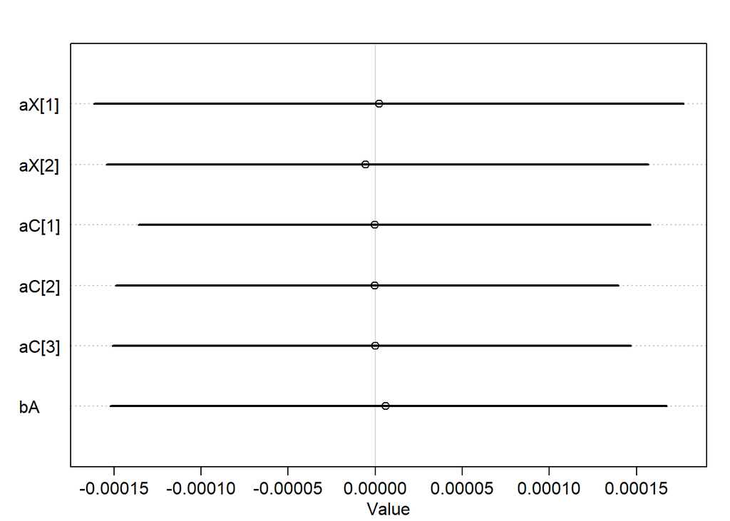

```r
precis_plot(precis(m1_2, depth = 2))
```

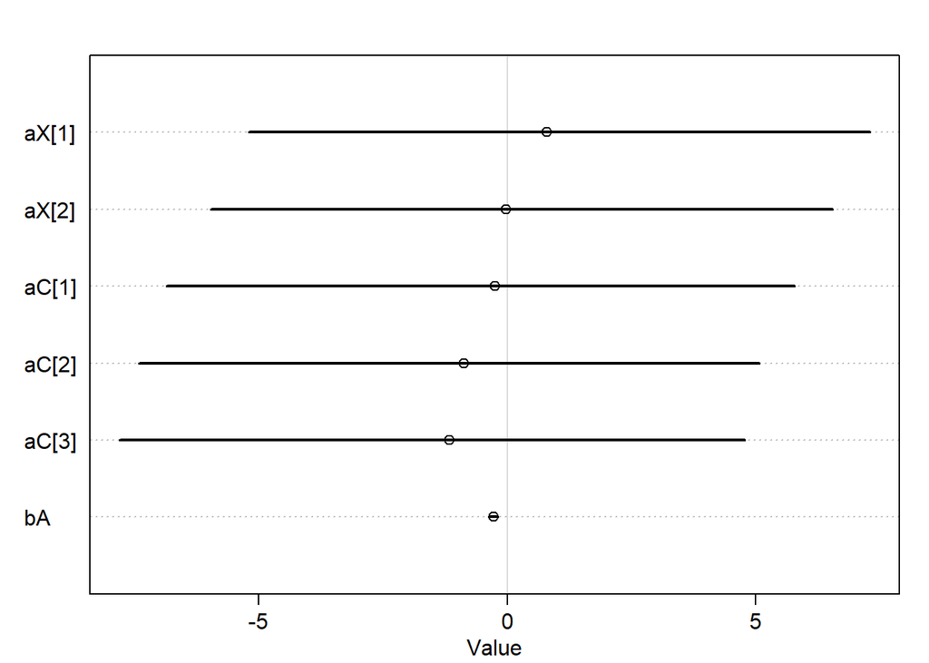

```r
precis_plot(precis(m1_3, depth = 2))
```

### A note on priors

```r
# Extracting priors
prior1 <- extract.prior(m1_1)
```

[output not shown]

```r
prior2 <- extract.prior(m1_2)
```

[output not shown]

```r
prior3 <- extract.prior(m1_3)
```

[output not shown]

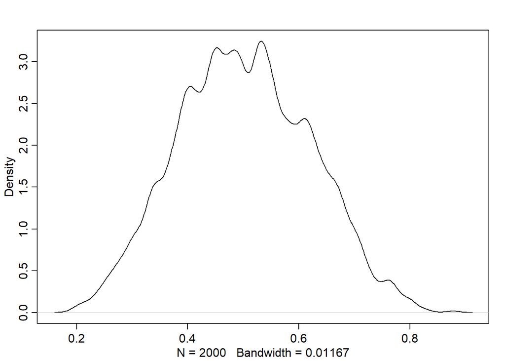

```r
dens(inv_logit(prior1$aX))
```

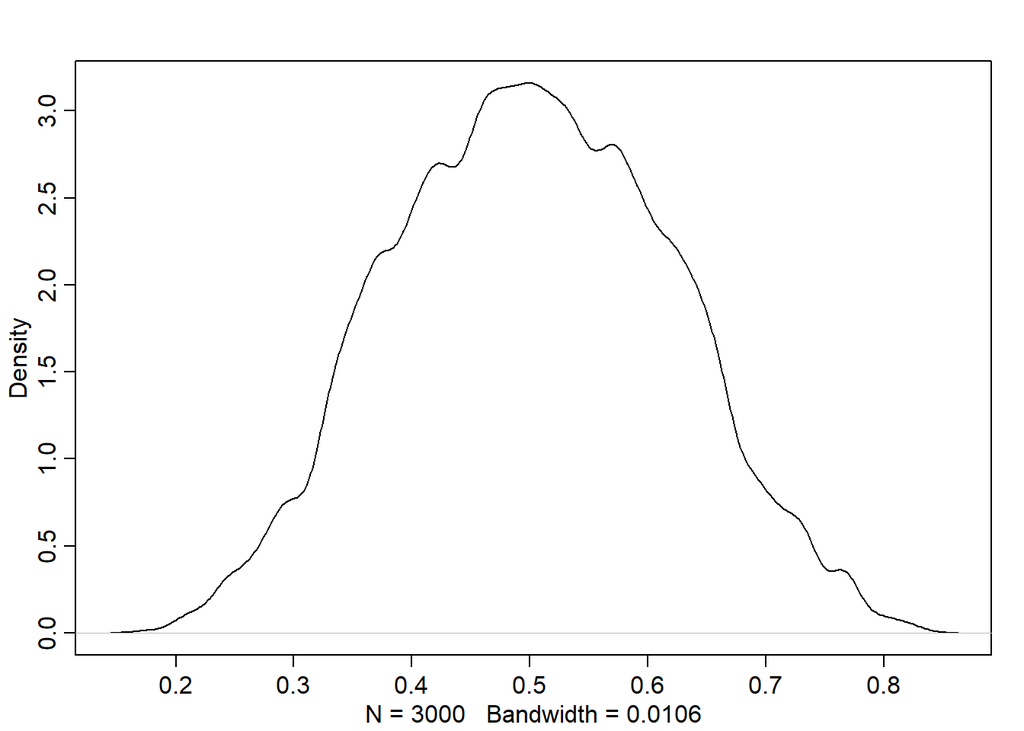

```r
dens(inv_logit(prior1$aC))
```

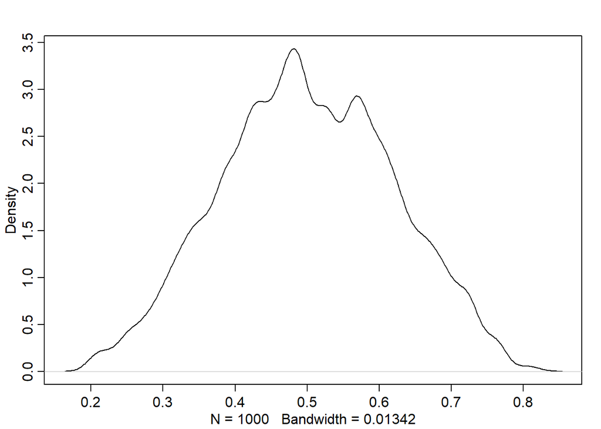

```r
dens(inv_logit(prior1$bA))
```

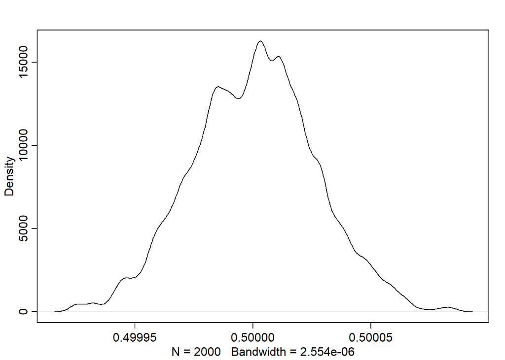

```r
dens(inv_logit(prior2$aX))
```

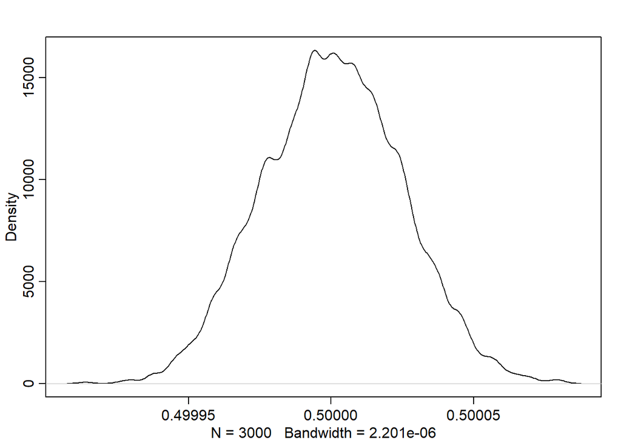

```r
dens(inv_logit(prior2$aC))
```

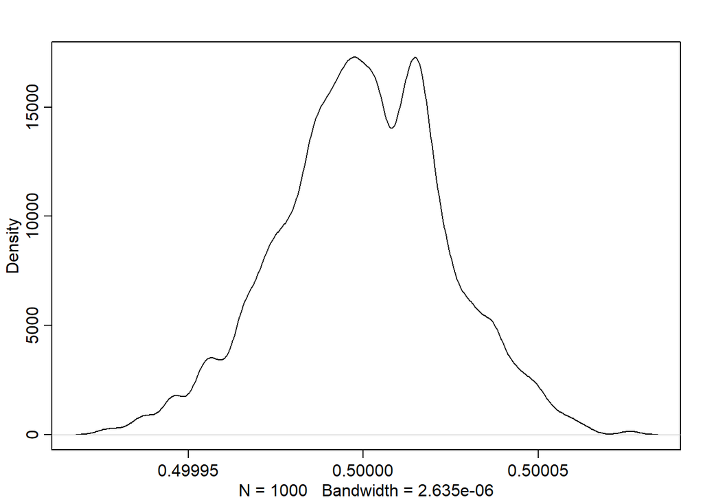

```r
dens(inv_logit(prior2$bA))
```

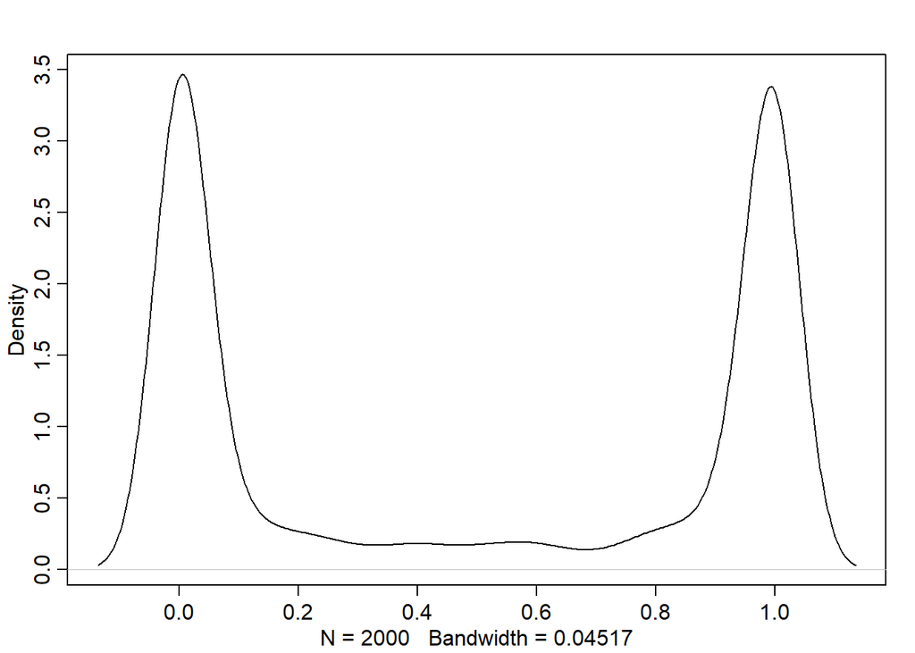

```r
dens(inv_logit(prior3$aX))
```

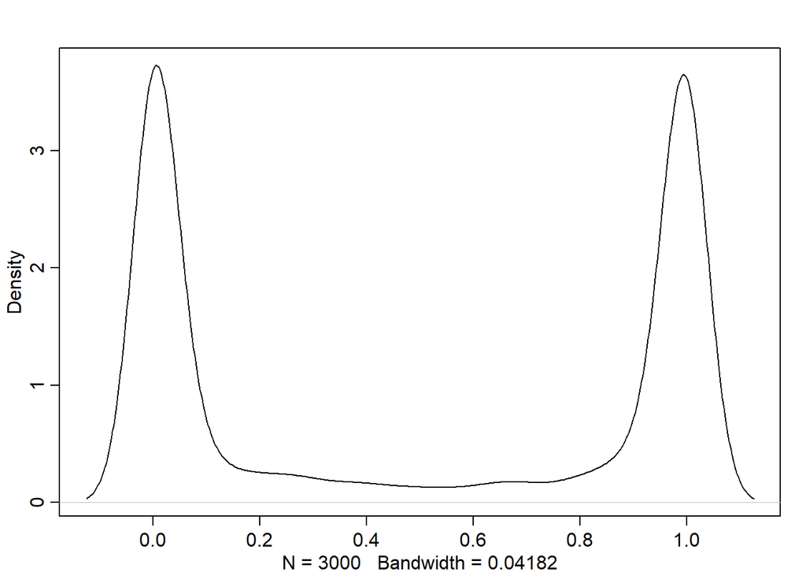

```r
dens(inv_logit(prior3$aC))
```

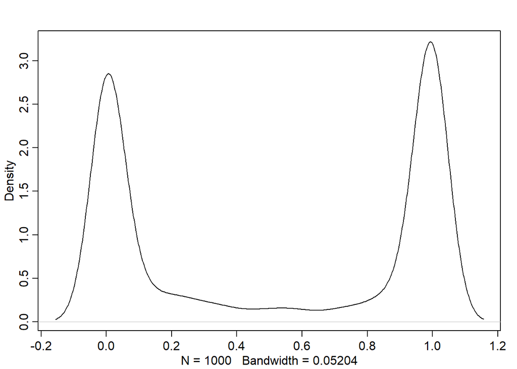

```r
dens(inv_logit(prior3$bA))
```

**These density plots confirm that my choice of priors. When using priors with a std of 10, the model is very sure of either surival or not, which i know isn’t the case in the data.**

### Testing conditional independencies

```r
impliedConditionalIndependencies(dag)
```

```
## A _||_ C
## A _||_ X
## C _||_ X
```

```r
# A _||_ C
m3 <- ulam(
  alist(

    ## A ~ C

    A ~ dnorm(mu, sigma),
    mu <- aC[C],
    aC[C] ~ dnorm(0, 0.5),
    sigma ~ dexp(1)

  ), data = dat_sim, log_lik = TRUE, refresh = 0
)
```

```
## Running MCMC with 1 chain, with 1 thread(s) per chain...
##
## Chain 1 finished in 2.1 seconds.
```

```r
# A _||_ X
# I need X as integer for it to be the outcome, otherwise i get an error
dat_sim_X <- dat_sim
dat_sim_X$X <- as.integer(dat_sim_X$X)-1

m4 <- ulam(
  alist(

    ## X ~ A

    X ~ dbinom(1, p),
    logit(p) <- a + bA*A,
    a ~ dnorm(0, 0.5),
    bA ~ dnorm(0, 0.5)

  ), data = dat_sim_X, log_lik = TRUE, refresh = 0
)
```

```
## Running MCMC with 1 chain, with 1 thread(s) per chain...
##
## Chain 1 finished in 3.1 seconds.
```

```r
# C _||_ X
m5 <- ulam(
  alist(

    ## X ~ C

    X ~ dbinom(1, p),
    logit(p) <- aC[C],
    aC[C] ~ dnorm(0, 0.5)

  ), data = dat_sim_X, log_lik = TRUE, refresh = 0
)
```

```
## Running MCMC with 1 chain, with 1 thread(s) per chain...
##
## Chain 1 finished in 3.1 seconds.
```

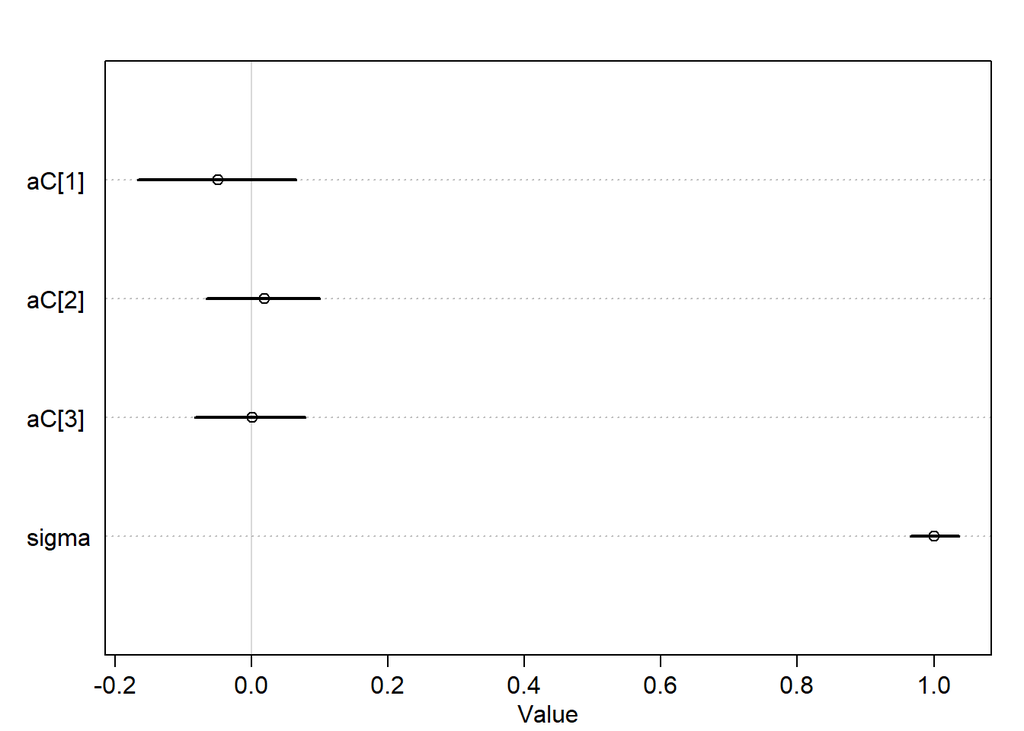

```r
precis_plot(precis(m3, depth = 2))
```

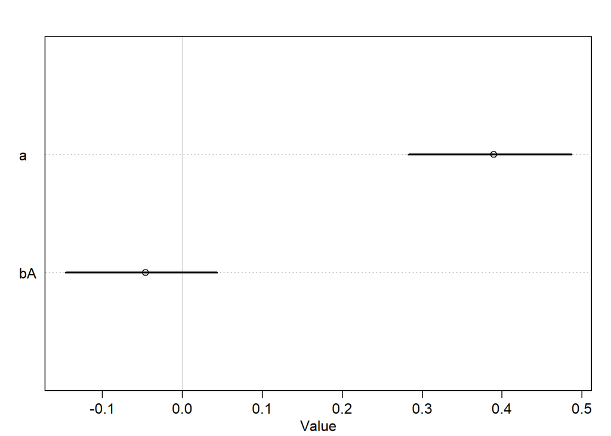

```r
precis_plot(precis(m4, depth = 2))
```

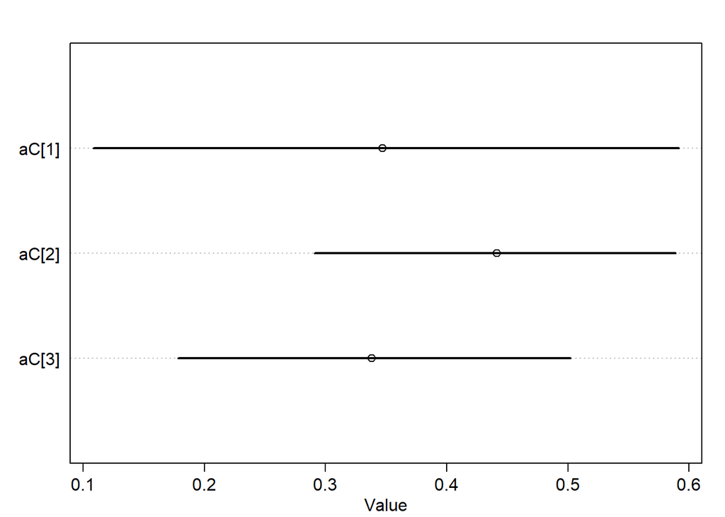

```r
precis_plot(precis(m5, depth = 2))
```

## 7. Assess whether the DAG is compatible with the data

Check the conditional independencies implied by the DAG are in the real data.

Remember adjustment sets. If they aren't, make a new DAG.

```r
adjustmentSets(dag, exposure = "X", outcome = "S")
```

```
##  {}
```

**I do not need to stratify on any variables to get the individual effects of my variables. Below is the total effects model using the real data.**

```r
# Preprocessing data
df_train <- df_train %>%
  select(Survived, Pclass, Age, Sex)

# Omitting NAs
df_train <- na.omit(df_train)

# Standardizing
dat = list(

  A = scale(df_train$Age),
  C = as.factor(df_train$Pclass),
  X = as.factor(df_train$Sex),
  S = as.integer(df_train$Survived)
)

# Total effects
m1_real <- ulam(
  alist(

    ## S ~ A + X + C

    S ~ dbinom(1, p),
    logit(p) <- aX[X] + aC[C] + bA*A,
    aX[X] ~ dnorm(0, 0.5),
    aC[C] ~ dnorm(0, 0.5),
    bA ~ dnorm(0, 0.5)

  ), data = dat, log_lik = TRUE, refresh = 0
)
```

```
## Running MCMC with 1 chain, with 1 thread(s) per chain...
##
## Chain 1 finished in 3.7 seconds.
```

```r
impliedConditionalIndependencies(dag)
```

```
## A _||_ C
## A _||_ X
## C _||_ X
```

```r
# Testing conditional independencies

# A _||_ C
m6 <- ulam(
  alist(

    ## A ~ C

    A ~ dnorm(mu, sigma),
    mu <- aC[C],
    aC[C] ~ dnorm(0, 0.5),
    sigma ~ dexp(1)

  ), data = dat, log_lik = TRUE, refresh = 0
)
```

```
## Running MCMC with 1 chain, with 1 thread(s) per chain...
```

[output not shown]

[output not shown]

[output not shown]

[output not shown]

```
## Chain 1
```

```
## Chain 1 finished in 1.5 seconds.
```

```r
# A _||_ X
# I need X as integer for it to be the outcome, otherwise i get an error
dat_X <- dat
dat_X$X <- as.integer(dat_X$X)-1

m7 <- ulam(
  alist(

    ## X ~ A

    X ~ dbinom(1, p),
    logit(p) <- a + bA*A,
    a ~ dnorm(0, 0.2),
    bA ~ dnorm(0, 0.5)

  ), data = dat_X, log_lik = TRUE, refresh = 0
)
```

```
## Running MCMC with 1 chain, with 1 thread(s) per chain...
##
## Chain 1 finished in 2.5 seconds.
```

```r
# C _||_ X
m8 <- ulam(
  alist(

    ## X ~ C

    X ~ dbinom(1, p),
    logit(p) <- aC[C],
    aC[C] ~ dnorm(0, 0.5)

  ), data = dat_X, log_lik = TRUE, refresh = 0
)
```

```
## Running MCMC with 1 chain, with 1 thread(s) per chain...
##
## Chain 1 finished in 2.2 seconds.
```

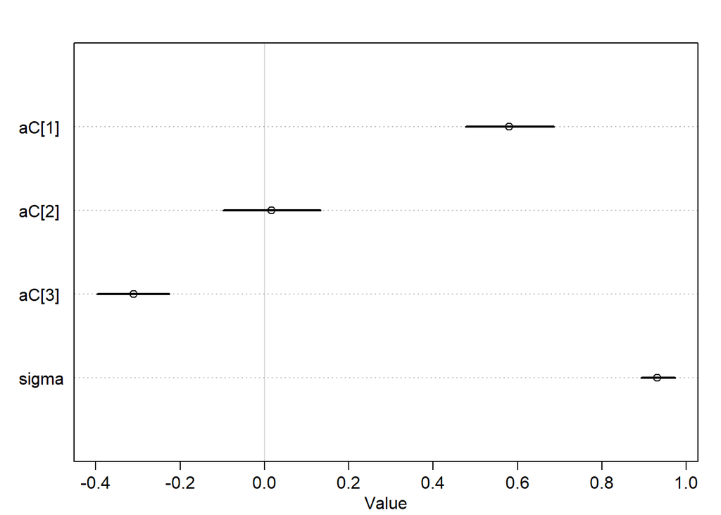

```r
precis_plot(precis(m6, depth = 2))
```

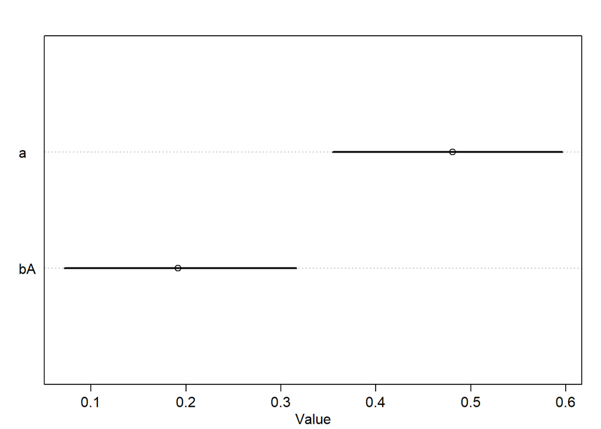

```r
precis_plot(precis(m7, depth = 2))
```

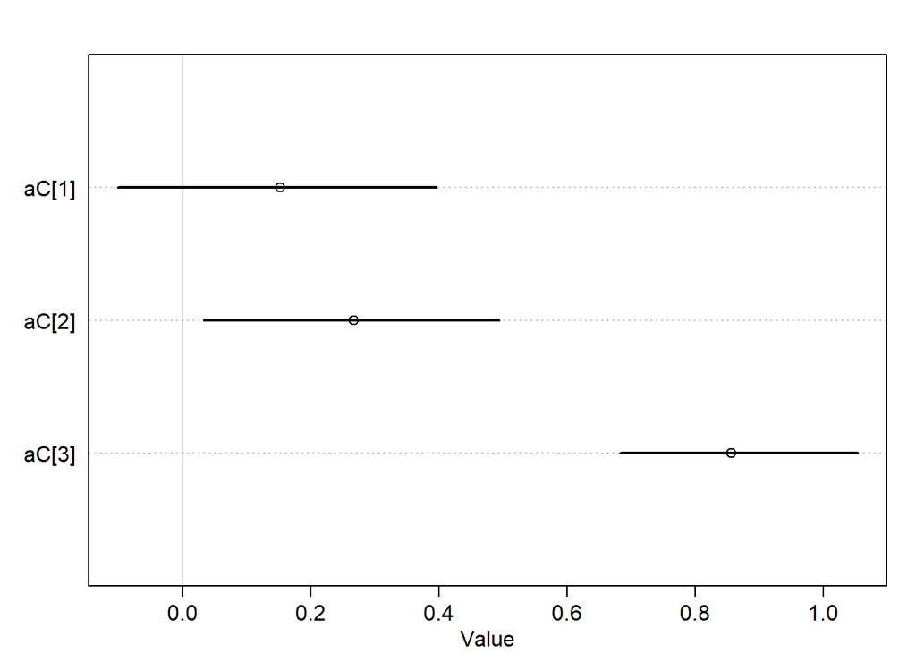

```r
precis_plot(precis(m8, depth = 2))
```

**It appears that i was too naive. In the real data, both age and sex seems to predict class in some way. I’ll incorporate this in a new DAG.**

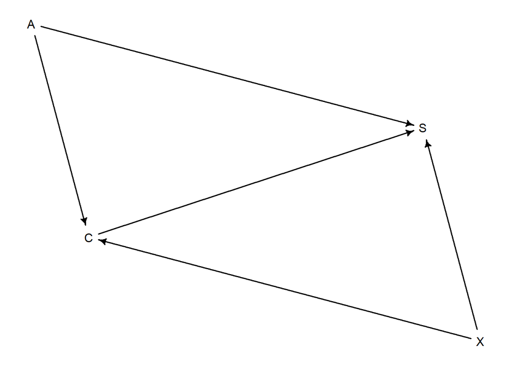

```r
dag2 <- dagitty( "dag {
    A -> S
    A -> C
    C -> S
    X -> S
    X -> C
}")

drawdag(dag2)
```

**This also makes for a much more interesting DAG. I’ll check the conditional independencies**

```r
impliedConditionalIndependencies(dag2)
```

```
## A _||_ X
```

```r
adjustmentSets(dag2, exposure = "A", outcome = "S")
```

```
##  {}
```

```r
adjustmentSets(dag2, exposure = "C", outcome = "S")
```

```
## { A, X }
```

```r
adjustmentSets(dag2, exposure = "X", outcome = "S")
```

```
##  {}
```

**This doesn’t change much regarding the statistical model structure, as I now know that i must include all three variables to not have any backdoors open. Therefore i will continue to include all three predictors in my model.**

## 8. Do model comparison

Try out some different priors.

Try with and without interactions.

Use Cross-Validation, PSIS and/or WAIC.

Use posterior predictive checks to make sure that the models don't make crazy predictions.

Select a model that you find reasonable. If none are, make a new one.

### Comparing my models with different priors

```r
# Modeling the real data with different priors

# Very narrow priors
m2_real <- ulam(
  alist(

    ## S ~ A + X + C

    S ~ dbinom(1, p),
    logit(p) <- aX[X] + aC[C] + bA*A,
    aX[X] ~ dnorm(0, 0.0001),
    aC[C] ~ dnorm(0, 0.0001),
    bA ~ dnorm(0, 0.0001)

  ), data = dat, log_lik = TRUE, refresh = 0
)
```

```
## Running MCMC with 1 chain, with 1 thread(s) per chain...
##
## Chain 1 finished in 3.3 seconds.
```

```r
# Very broad priors
m3_real <- ulam(
  alist(

    ## S ~ A + X + C

    S ~ dbinom(1, p),
    logit(p) <- aX[X] + aC[C] + bA*A,
    aX[X] ~ dnorm(0, 10),
    aC[C] ~ dnorm(0, 10),
    bA ~ dnorm(0, 10)

  ), data = dat, log_lik = TRUE, refresh = 0
)
```

```
## Running MCMC with 1 chain, with 1 thread(s) per chain...
##
## Chain 1 finished in 15.9 seconds.
```

```r
# Comparing model with different priors

compare(m1_real, m2_real, m3_real)
```

|  | WAIC | SE | dWAIC | dSE | pWAIC | weight |
| --- | --- | --- | --- | --- | --- | --- |
| m3_real | 657.6734 | 3.162716e+01 | 0.0000000 | NA | 5.119703e+00 | 5.964114e-01 |
| m1_real | 658.4544 | 2.835706e+01 | 0.7810693 | 3.707587 | 4.027538e+00 | 4.035886e-01 |
| m2_real | 989.8140 | 1.587063e-04 | 332.1406251 | 31.649322 | 4.994756e-06 | 4.488752e-73 |

```r
compare(m1_real, m2_real, m3_real, func = PSIS)
```

|  | PSIS | SE | dPSIS | dSE | pPSIS | weight |
| --- | --- | --- | --- | --- | --- | --- |
| m3_real | 657.7920 | 3.165650e+01 | 0.0000000 | NA | 5.179022e+00 | 5.901128e-01 |
| m1_real | 658.5209 | 2.837970e+01 | 0.7288632 | 3.71208 | 4.060753e+00 | 4.098872e-01 |
| m2_real | 989.8140 | 1.588177e-04 | 332.0219884 | 31.65649 | 5.028038e-06 | 4.712771e-73 |

**Even though the model with too broad priors has lower WAIC and PSIS score than my optimal-prior model, I know that this model doesn’t make sense with my knowledge of the data.**

### Making contrast plots for models with different priors

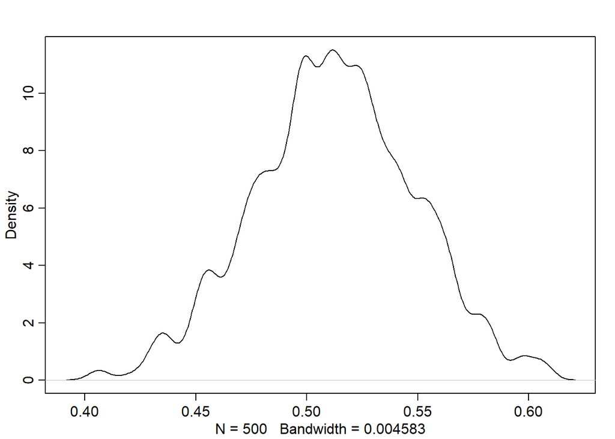

```r
# Contrast plots

posterior1 <- extract.samples(m1_real)
posterior2 <- extract.samples(m2_real)
posterior3 <- extract.samples(m3_real)

dens(inv_logit(posterior1$aX[,1]) - inv_logit(posterior1$aX[,2]))
```

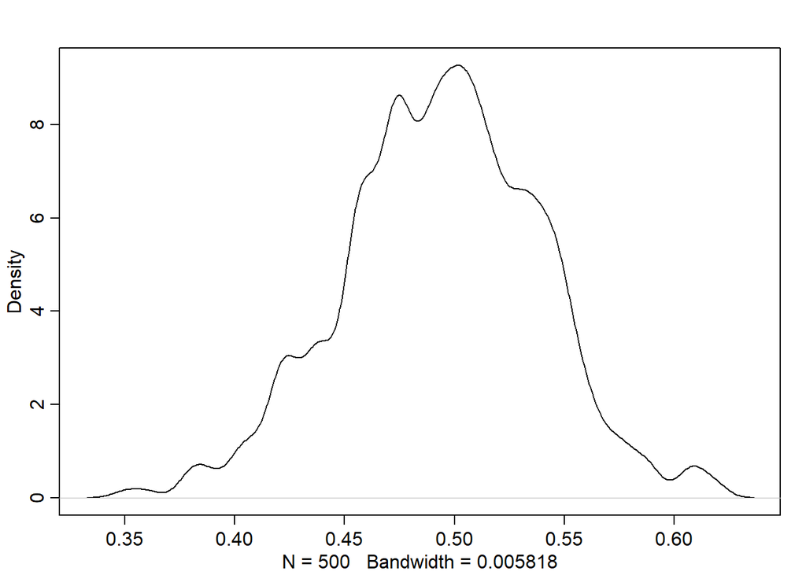

```r
dens(inv_logit(posterior1$aC[,1]) - inv_logit(posterior1$aC[,3]))
```

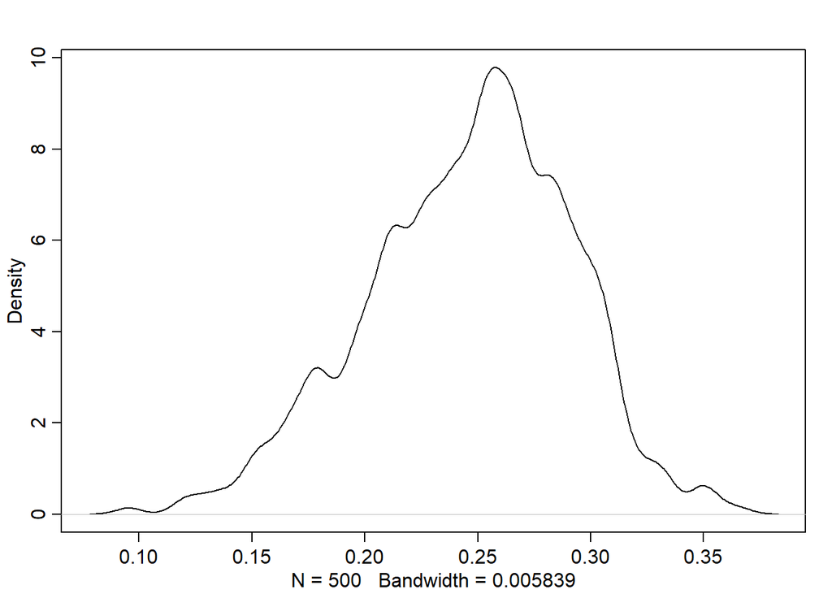

```r
dens(inv_logit(posterior2$aX[,1]) - inv_logit(posterior1$aX[,2]))
```

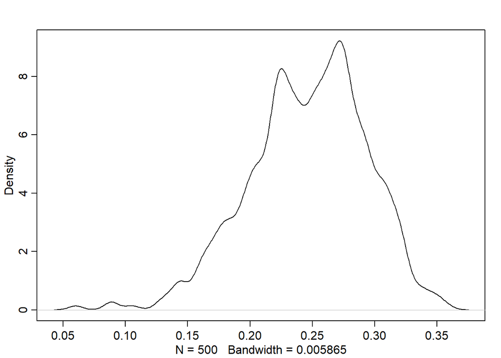

```r
dens(inv_logit(posterior2$aC[,1]) - inv_logit(posterior1$aC[,3]))
```

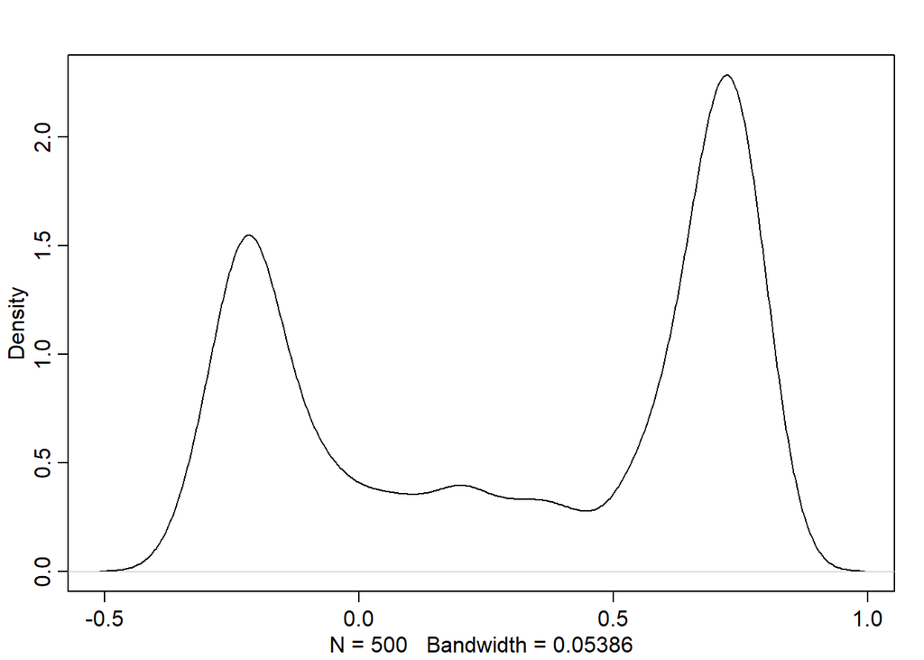

```r
dens(inv_logit(posterior3$aX[,1]) - inv_logit(posterior1$aX[,2]))
```

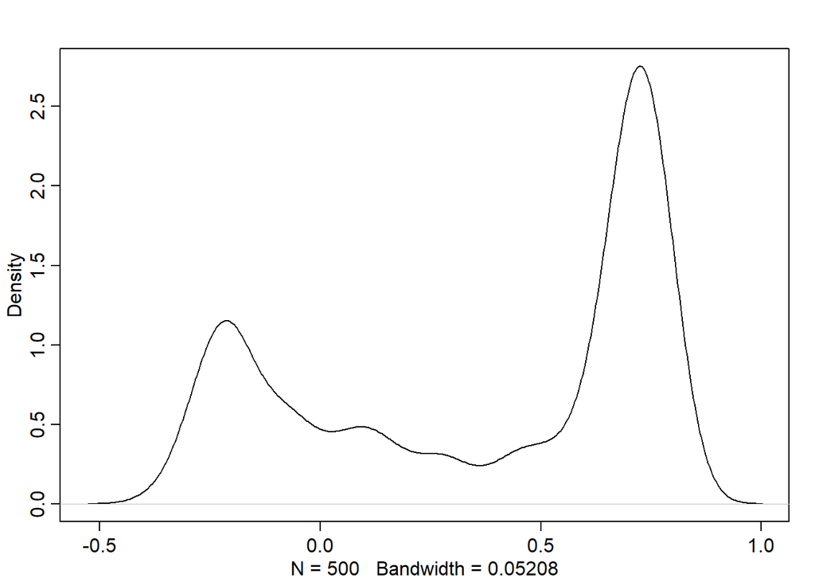

```r
dens(inv_logit(posterior3$aC[,1]) - inv_logit(posterior1$aC[,3]))
```

**These contrast plots confirm my choice of prior, spanning the values which I expect.**

### Trying out a model with an interaction between sex and class

```r
# Interaction between sex and class
m1_real_int <- ulam(
  alist(

    #

    S ~ dbinom(1, p),
    logit(p) <- I[X,C]+ bA*A,
    matrix[X,C]:I ~ normal(0, 0.5),
    bA ~ dnorm(0, 0.5)
    ), data=dat, cores = 4, log_lik = TRUE, refresh = 0)
```

```
## Running MCMC with 1 chain, with 1 thread(s) per chain...
##
## Chain 1 finished in 2.6 seconds.
```

```r
# Checking the parameter estimates
precis(m1_real_int, depth=3)
```

|  | mean | sd | 5.5% | 94.5% | n_eff | Rhat4 |
| --- | --- | --- | --- | --- | --- | --- |
| I[1,1] | 2.08457836 | 0.2602120 | 1.7002177 | 2.49970600 | 498.8020 | 0.9981777 |
| I[1,2] | 1.64875298 | 0.2760031 | 1.2077089 | 2.10589710 | 680.6177 | 0.9980042 |
| I[1,3] | -0.34782657 | 0.2093292 | -0.6827372 | -0.03791217 | 434.5707 | 1.0074117 |
| I[2,1] | -0.08372761 | 0.2059725 | -0.4076136 | 0.23417549 | 419.5008 | 1.0001252 |
| I[2,2] | -1.38188686 | 0.2241788 | -1.7636573 | -1.03886710 | 479.6641 | 0.9995389 |
| I[2,3] | -1.69650684 | 0.1556185 | -1.9543696 | -1.46355995 | 325.4924 | 1.0004286 |
| bA | -0.44412329 | 0.1072625 | -0.6258452 | -0.27115363 | 353.0420 | 0.9991608 |

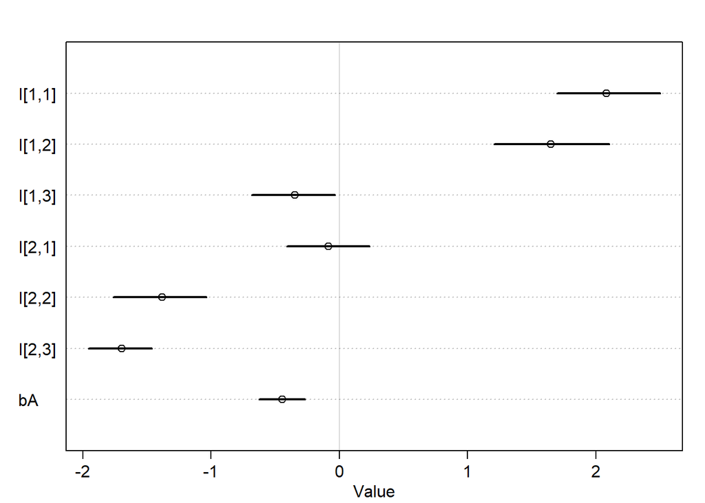

```r
precis_plot(precis(m1_real_int, 3))
```

```r
# Extracting the priors
prior_interaction_model<- extract.prior(m1_real_int)
```

[output not shown]

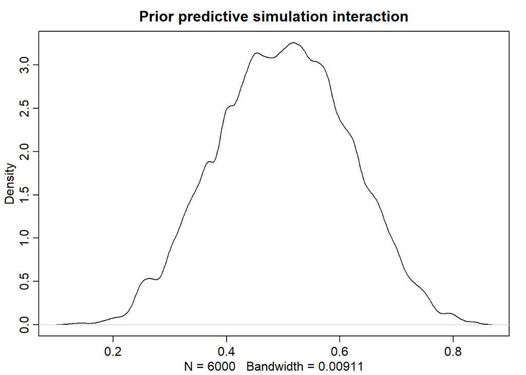

```r
# Density plots of prior
p_I <- inv_logit(prior_interaction_model$I)
dens(p_I, main= "Prior predictive simulation interaction")
```

**The interaction model shows that for both sexes, 1st class is the safest. Though for females, 1st and 2nd class are close to each other, with 3rd class being less safe. For males, both 2nd and 3rd class are relatively unsafe compared to 1st class. The prior predictive simulation simply shows that my prior is still reasonable.**

```r
# Comparing interaction model to no interaction model
compare(m1_real, m1_real_int)
```

|  | WAIC | SE | dWAIC | dSE | pWAIC | weight |
| --- | --- | --- | --- | --- | --- | --- |
| m1_real_int | 643.7438 | 24.79530 | 0.00000 | NA | 4.955344 | 0.9993612357 |
| m1_real | 658.4544 | 28.35706 | 14.71067 | 7.912899 | 4.027538 | 0.0006387643 |

**The interaction model also has a slightly lower WAIC score, and a smaller standard error as well.**

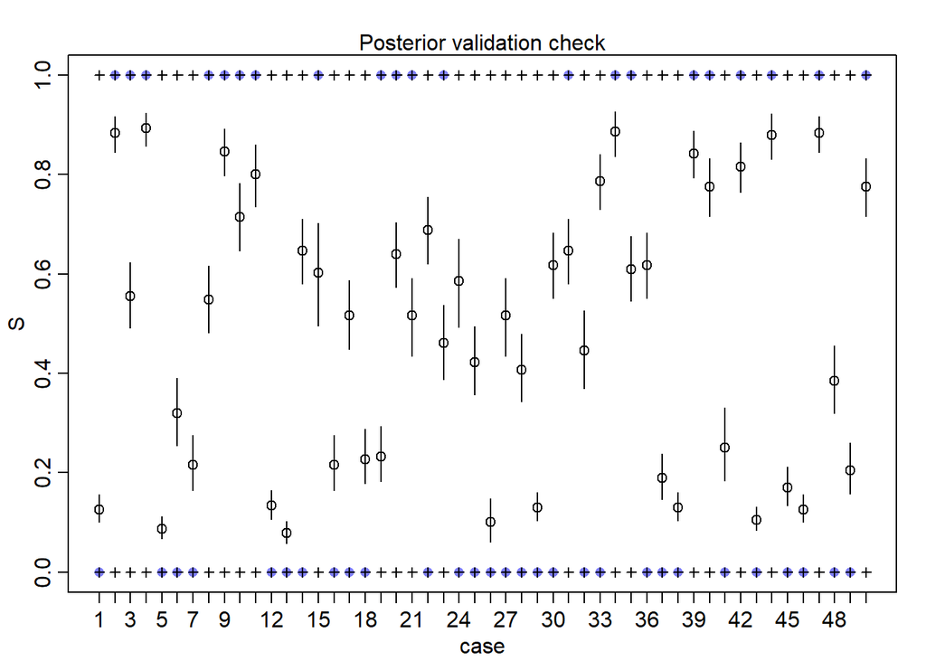

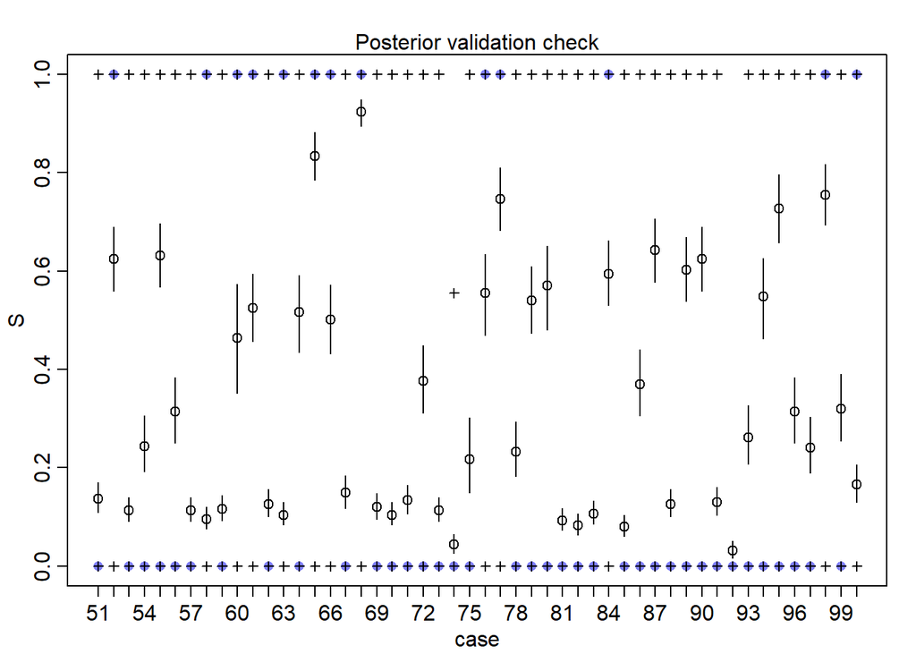

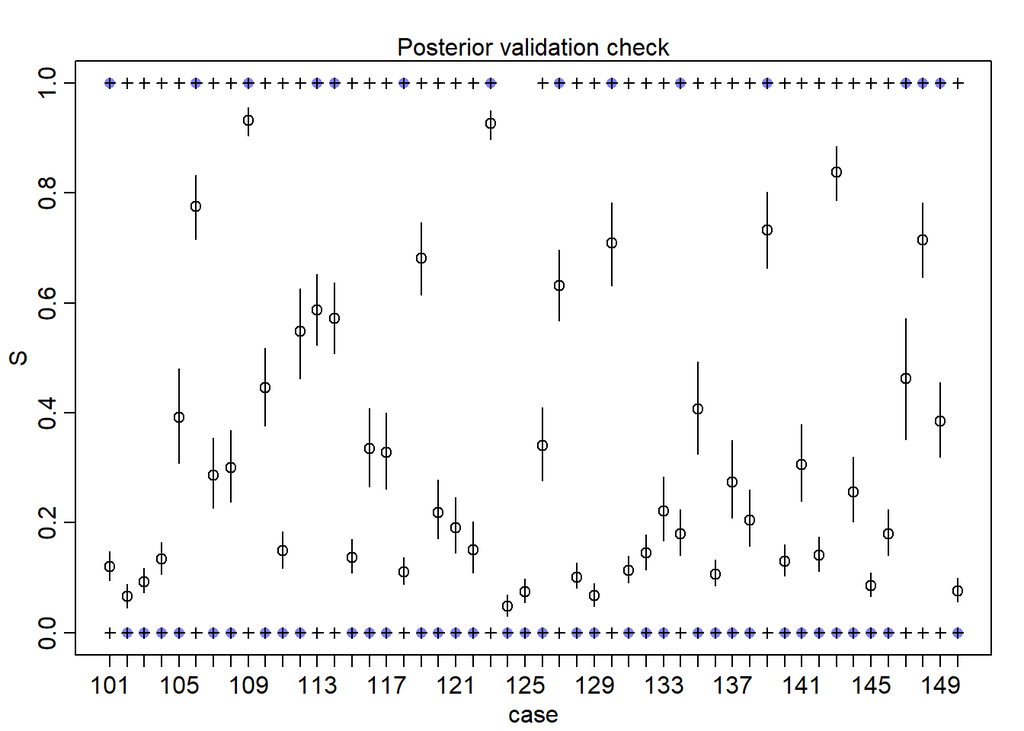

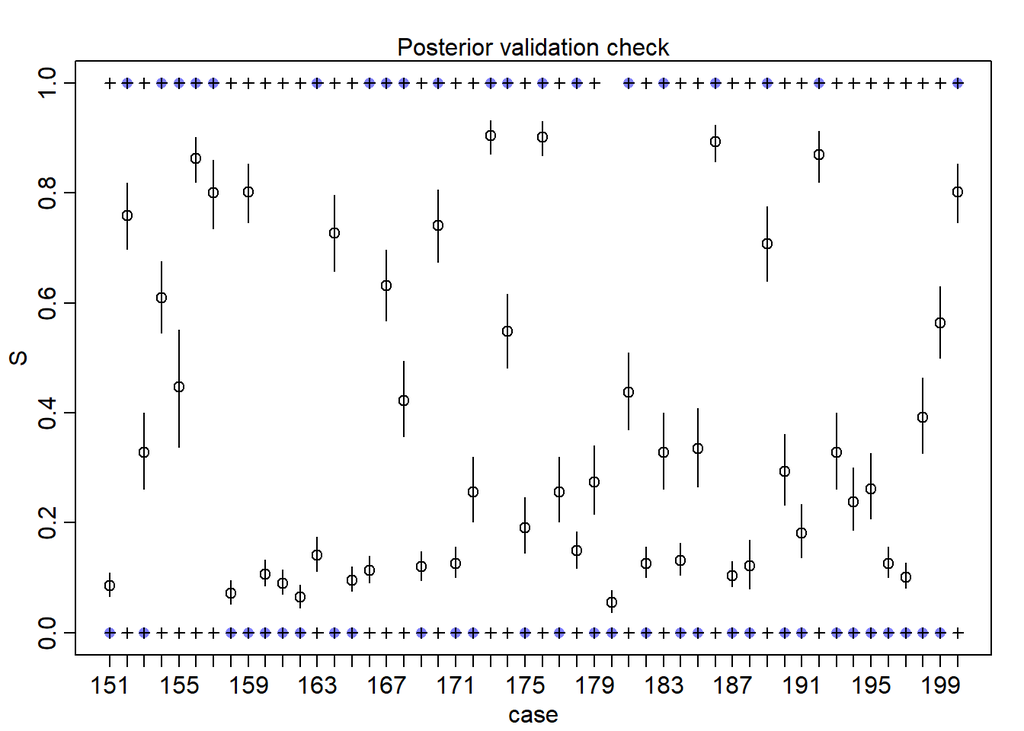

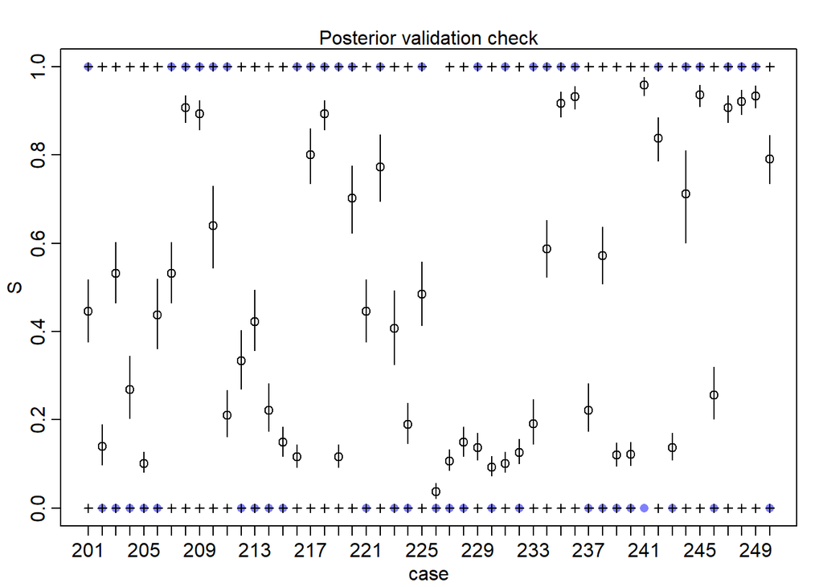

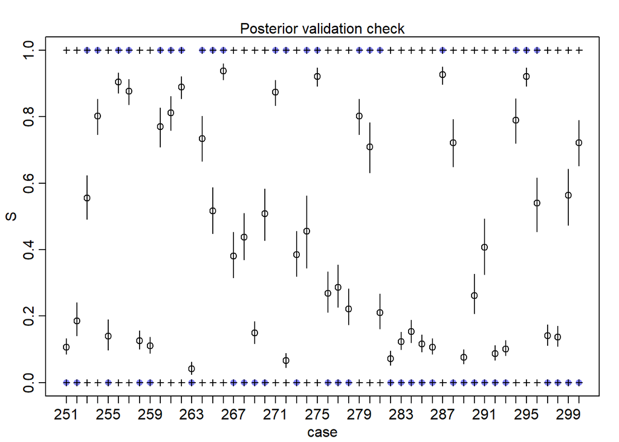

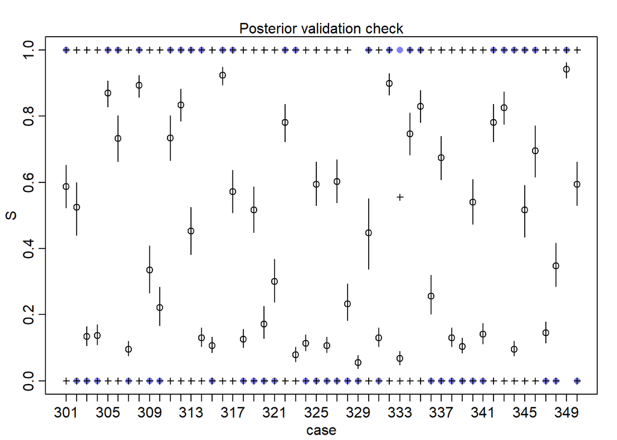

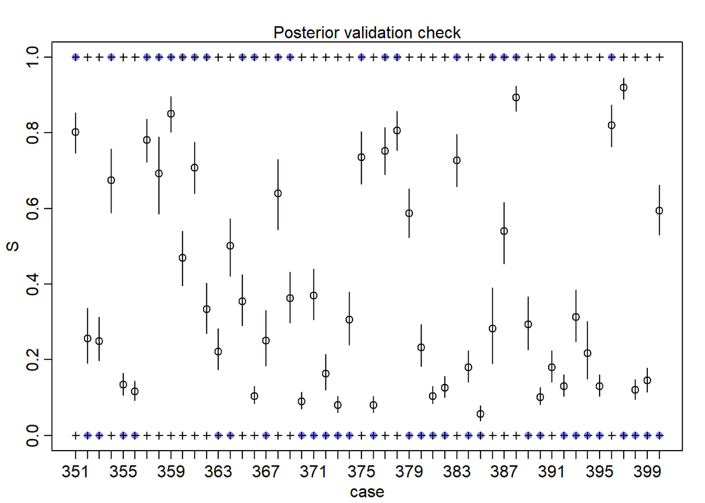

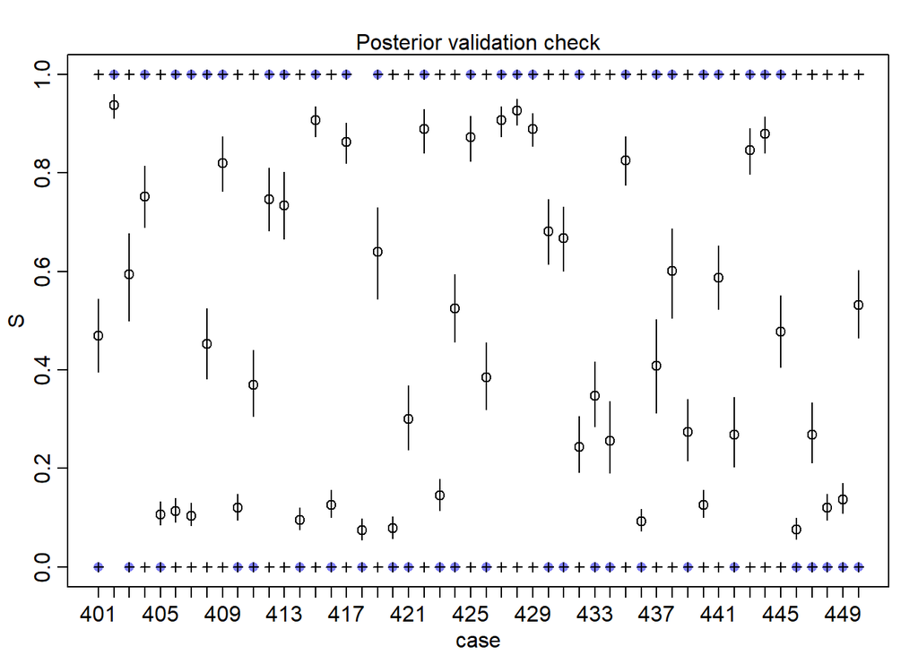

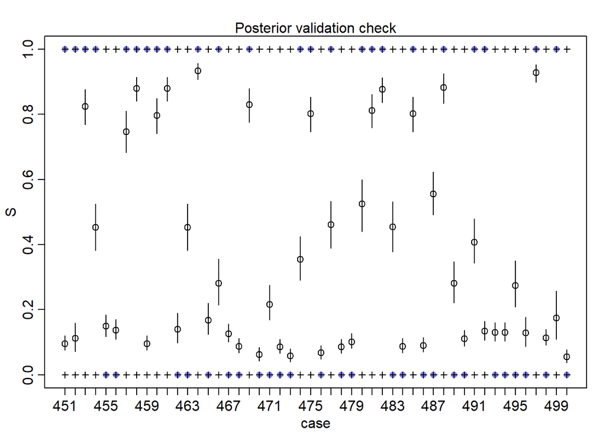

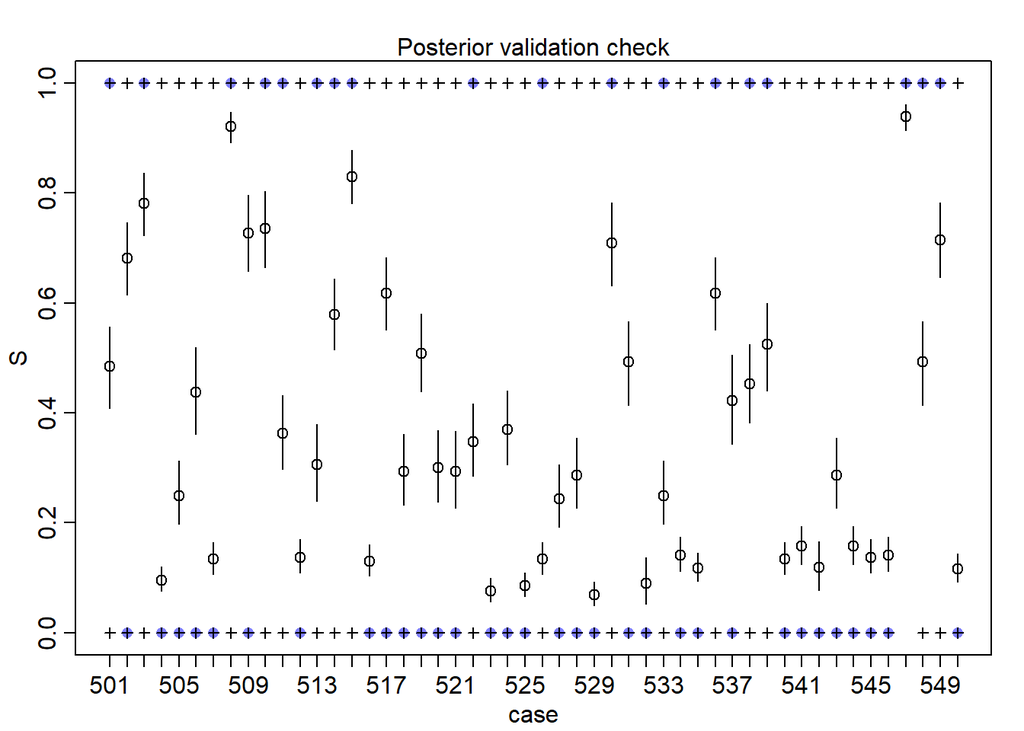

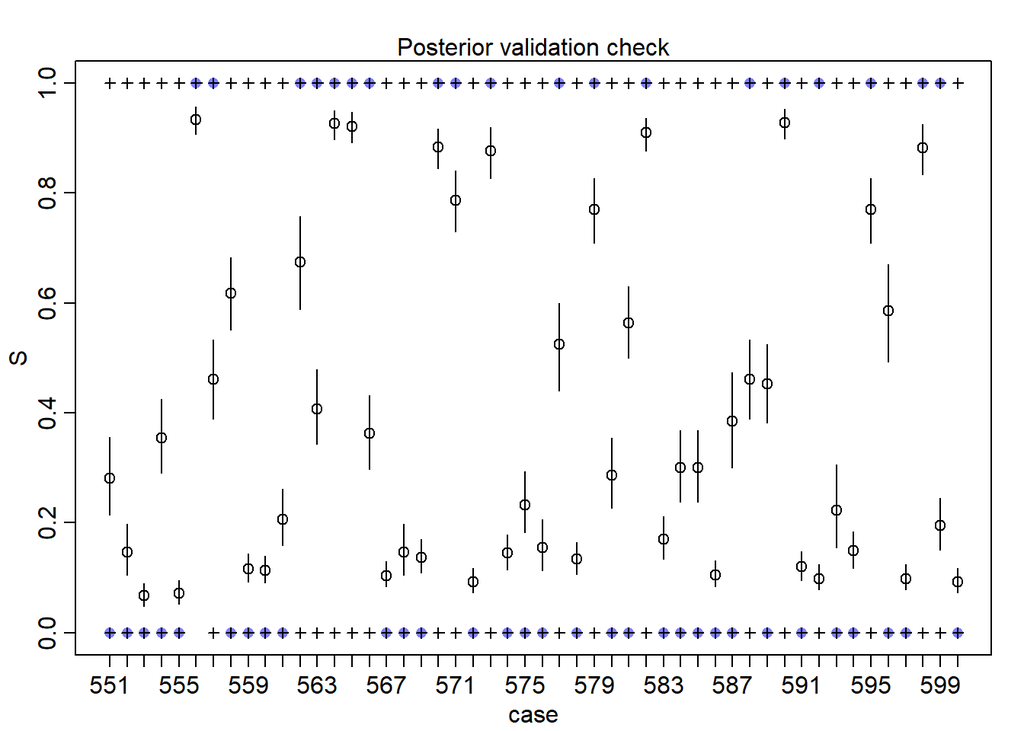

[3 more figures not shown]

```r
# Posterior validation check to see predictions
rethinking::postcheck(m1_real, window = 50)
```

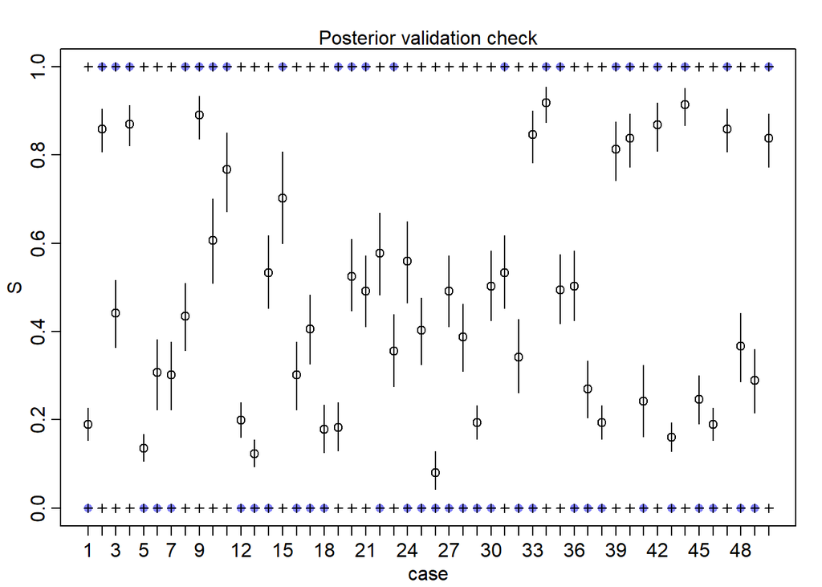

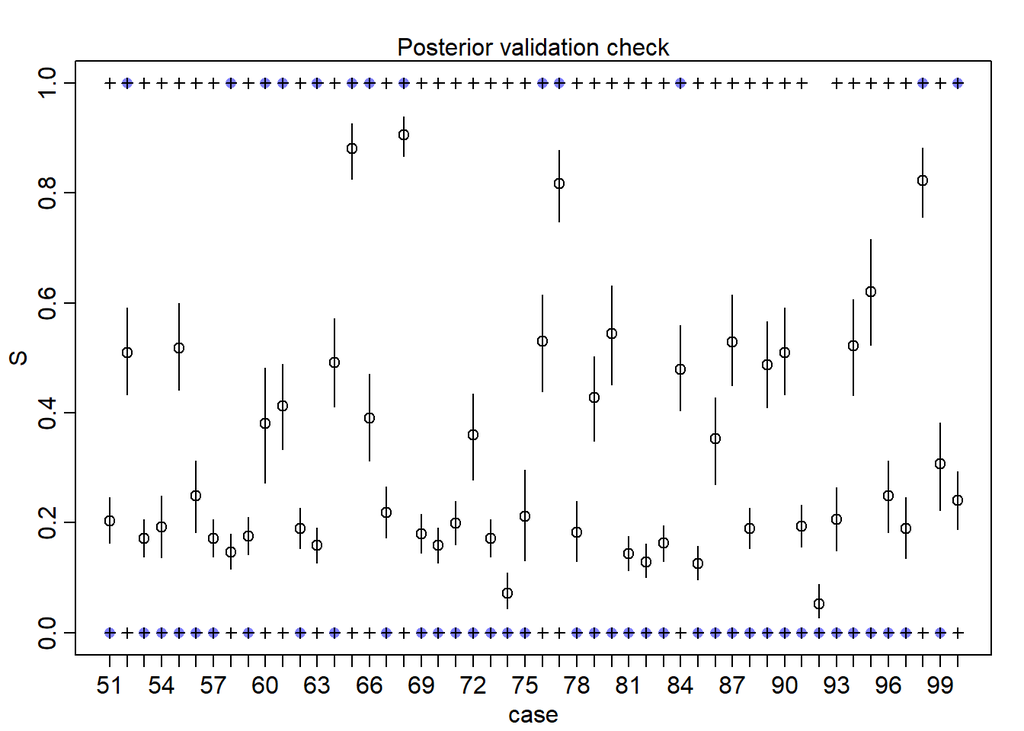

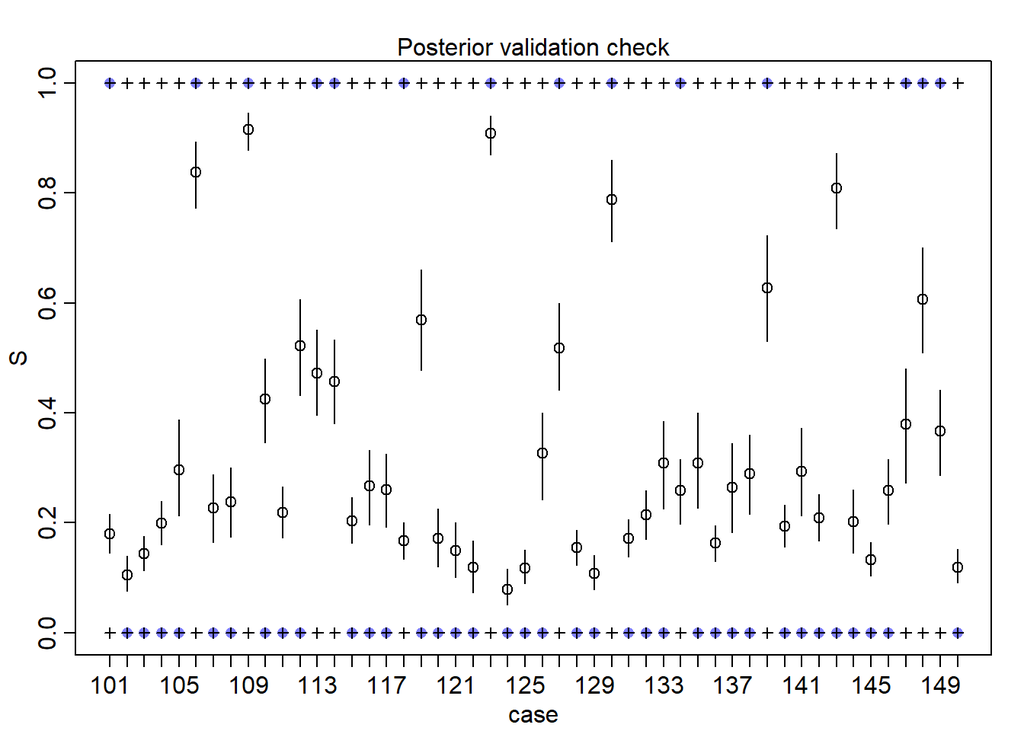

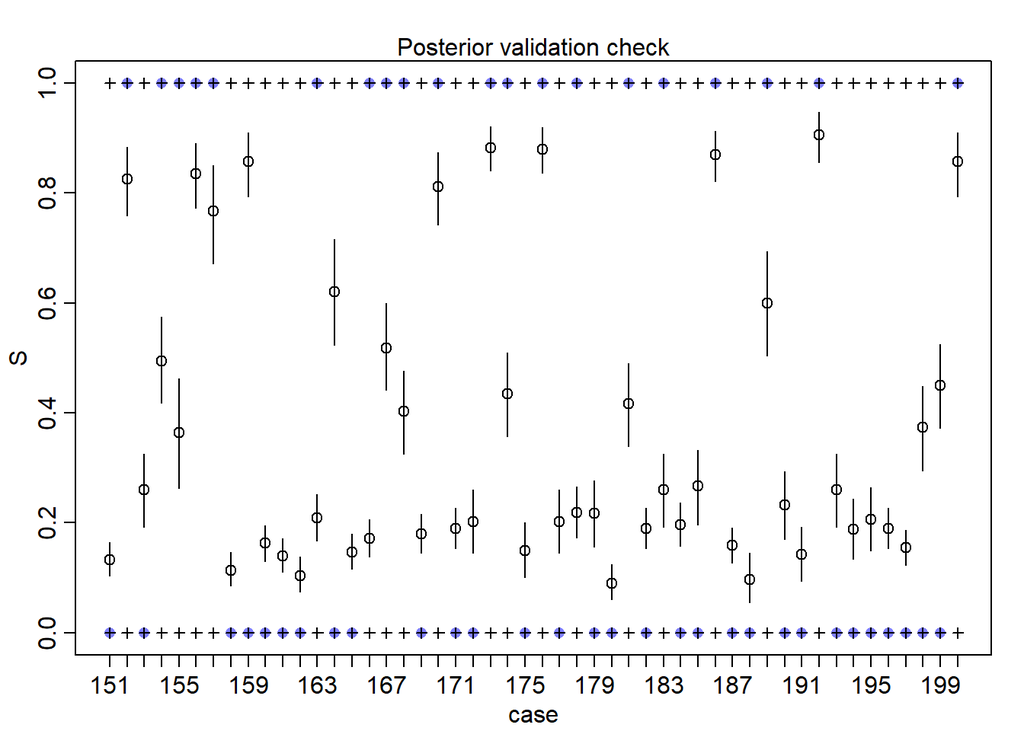

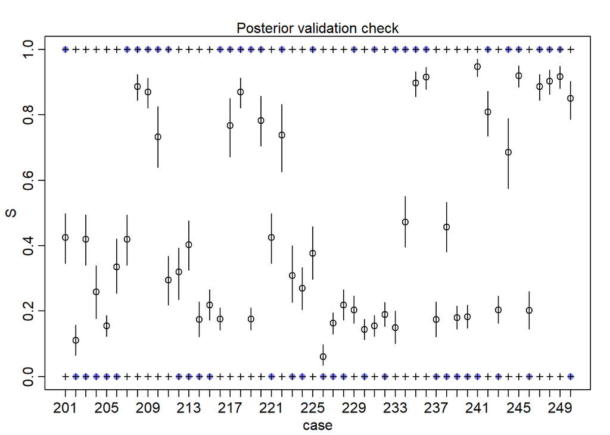

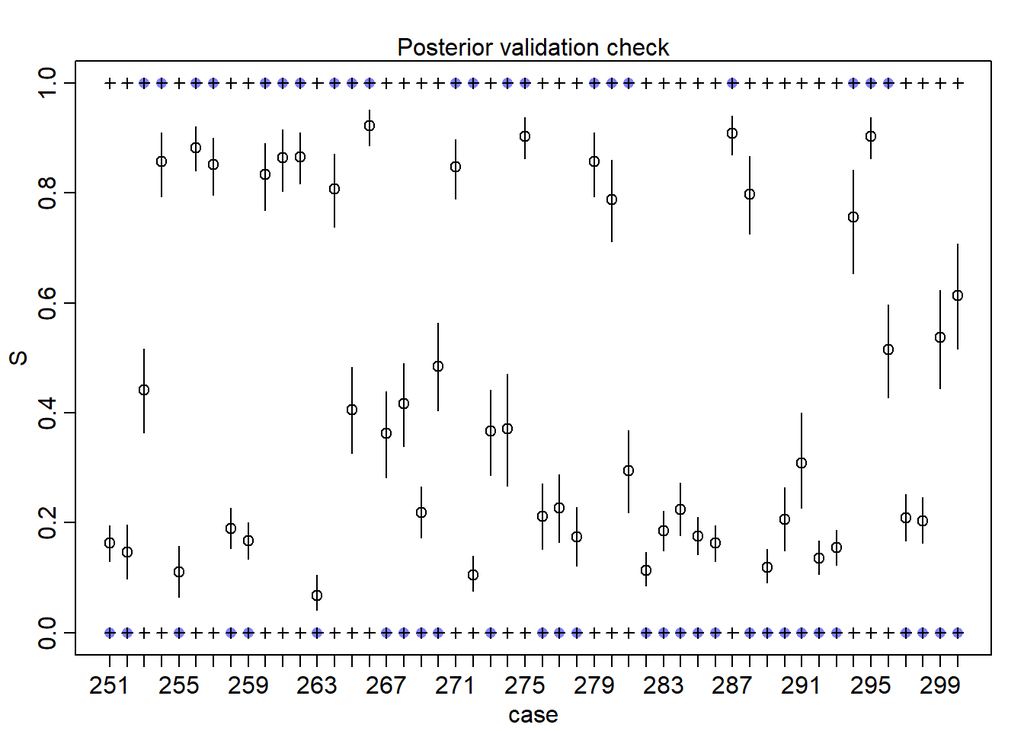

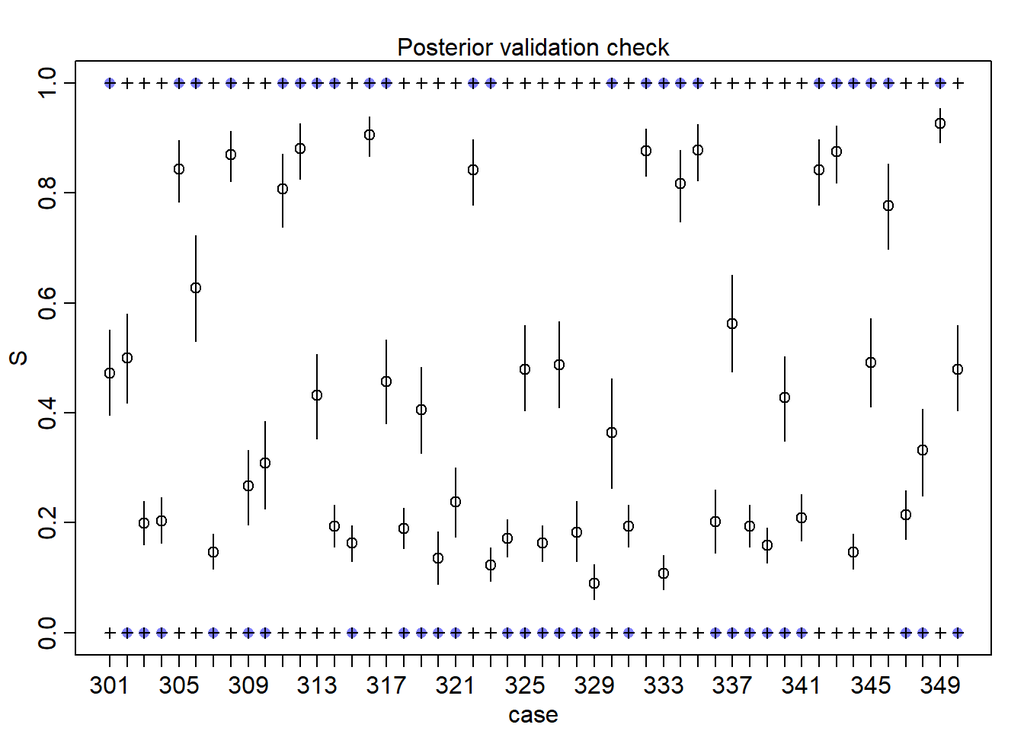

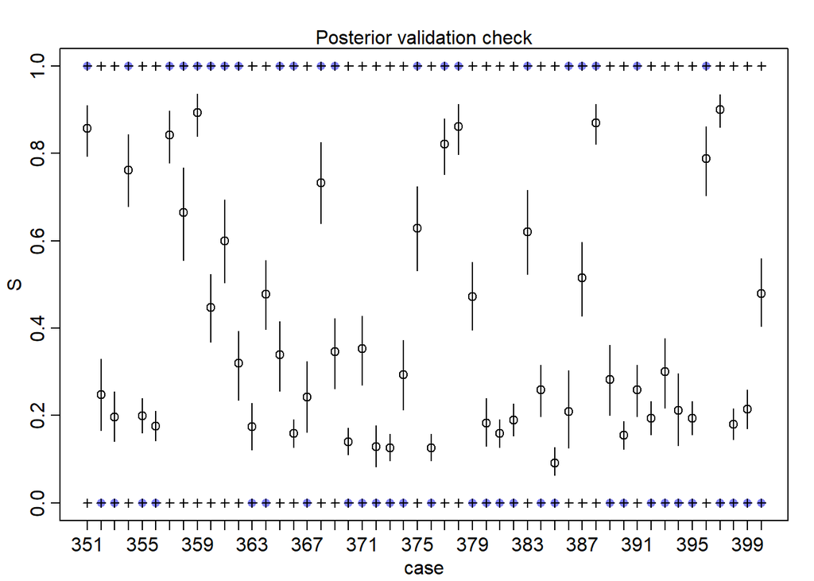

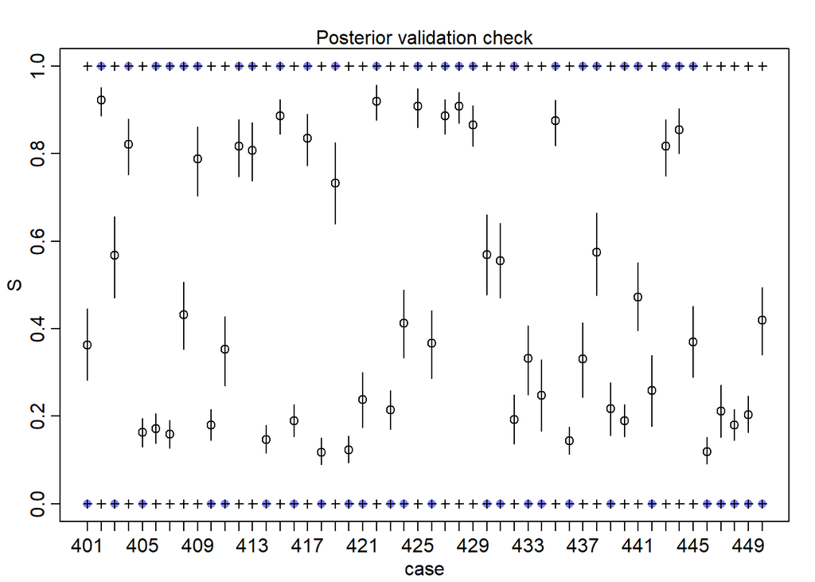

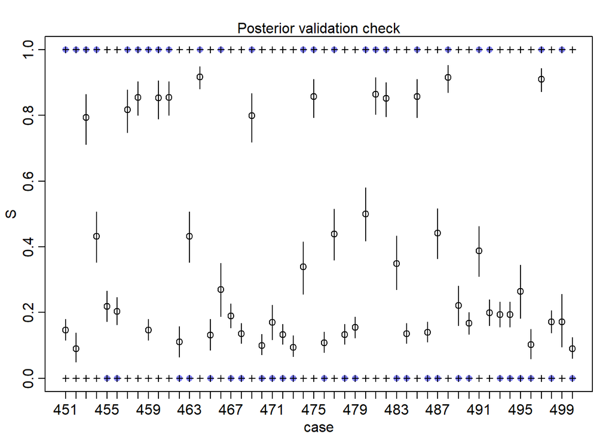

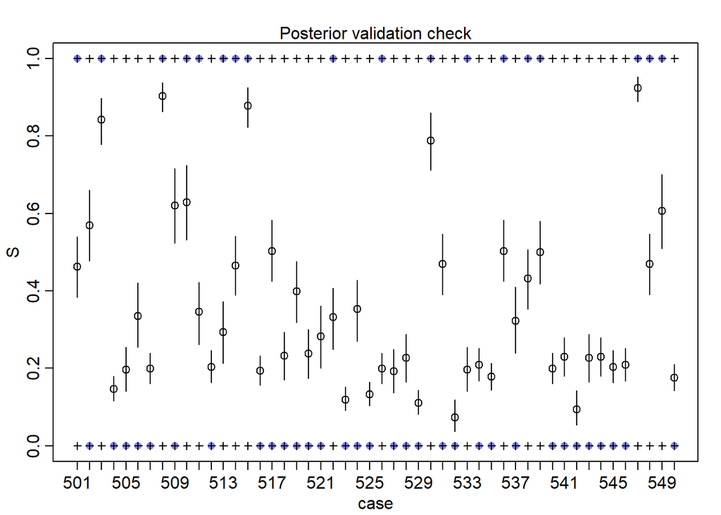

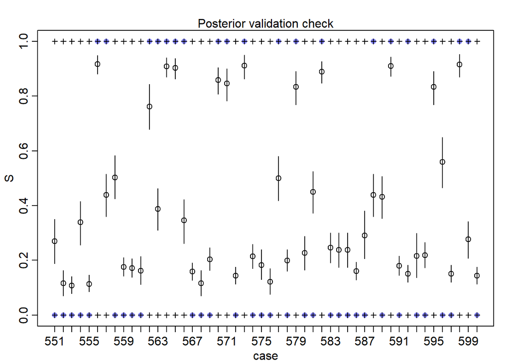

[3 more figures not shown]

```r
rethinking::postcheck(m1_real_int, window = 50)
```